# BVSGH: ipilimumab trial

This example uses the reconstructed overall survival data of the CA184-043 trial (Supplementary Section 1).

```r
knitr::opts_chunk$set(comment = "", fig.width = 7, fig.height = 4.5)
BVS_CORE <- normalizePath("./core")
library(mvtnorm); library(survival); library(glmnet)
source(file.path(BVS_CORE, "ADS_sampler.R"))
source(file.path(BVS_CORE, "utils", "map_estimates.R"))
source("real_application/prepare_data.R")

role <- c("1" = "^time", "2" = "^haz", "3" = "", "4" = "")
label <- function(s, vars) {
  g <- strsplit(s, "")[[1]]; i <- which(g != "0")
  if (!length(i)) return("null")
  paste0("{", paste0(vars[i], role[g[i]], collapse = ", "), "}^", gam2haz(s))
}
```

## Data and standard analyses

```r
S <- prep.ipilimumab(file = "real_application/data/CA184043_2A.csv")  # S$df: data frame; S$dat: input for BVS.MCMC
c(n = nrow(S$df), events = sum(S$df$status))
```

```
     n events
   799    561
```

```r
summary(coxph(Surv(time, status) ~ trt, data = S$df))$coefficients
```

```
         coef exp(coef)   se(coef)         z   Pr(>|z|)
trt -0.158951 0.8530382 0.08480841 -1.874236 0.06089794
```

```r
summary(survreg(Surv(time, status) ~ trt, data = S$df, dist = "lognormal"))$table["trt", ]
```

```
       Value   Std. Error            z            p
-0.005987205  0.078049140 -0.076710708  0.938853686
```

Neither the Cox PH model nor the log-normal AFT model detects a treatment effect.

## Proposed method

The model space is either the whole GH family or restricted to PH or AFT models, through the weights $h = (h_{AH}, h_{PH}, h_{GH}, h_{AFT})$ of the model-space prior (`gamprior = "custom"`). With one covariate there are only five models, all of which the sampler evaluates, so the probabilities are exact.

```r
spaces <- list(GH = c(1, 1, 1, 1),
               PH = c(0, 1, 0, 0),
               AFT = c(0, 0, 0, 1))
fit.space <- function(dat, h) {
  p <- ncol(dat$x)
  modelpar <- list(inits = list(nu = 0, theta0 = 0,
                                theta = rep(0, p), eta = rep(0, p),
                                g = 1, a_g = NULL, gam = rep(0, p),
                                nu.alpha = 0.01, nu.beta = 0.01),
                   gam.param = list(layer1.betabin.par = c(1, 1), layer2.mulnom.par = h, layer3.beta.par = 1/3),
                   data = dat)
  BVS.MCMC(modelpar, list(n.iter = 5000, n.burnin = 1000, n.thin = 2, n.chain = 1, printevery = 1e9),
           gprior.mat = "LCM", gamprior = "custom", verbose = FALSE)
}
set.seed(1)
fits <- lapply(spaces, function(h) fit.space(S$dat, h))
lapply(fits, function(f)
  data.frame(model = sapply(f$post.prob$Vars, label, vars = "trt"), prob = round(f$post.prob$prob, 3),
             row.names = NULL))
```

```
$GH
          model  prob
1 {trt^time}^AH 0.851
2      {trt}^GH 0.149
3          null 0.000
4  {trt^haz}^PH 0.000
5     {trt}^AFT 0.000

$PH
         model  prob
1         null 0.814
2 {trt^haz}^PH 0.186

$AFT
      model  prob
1      null 0.952
2 {trt}^AFT 0.048
```

Posterior probability that treatment enters the model under each hazard structure assumption:

```r
sapply(fits, function(f) round(sum(f$post.prob$prob[f$post.prob$Vars != "0"]), 3))
```

```
   GH    PH   AFT
1.000 0.186 0.048
```

Restricted to PH or AFT models, the null model is preferred; with the hazard structure selected jointly, the treatment effect is detected through a time-level (AH) effect, which allows the survival curves to cross. The estimated posterior distribution of the hazard structures under the GH model space is:

```r
round(fits$GH$haz.post,3)
```

```
 Null    AH    PH   AFT    GH
0.000 0.851 0.000 0.000 0.149
```

## Fitted survival curves

Kaplan-Meier estimates and the survival functions of the top model of the joint analysis, at its MAP estimates:

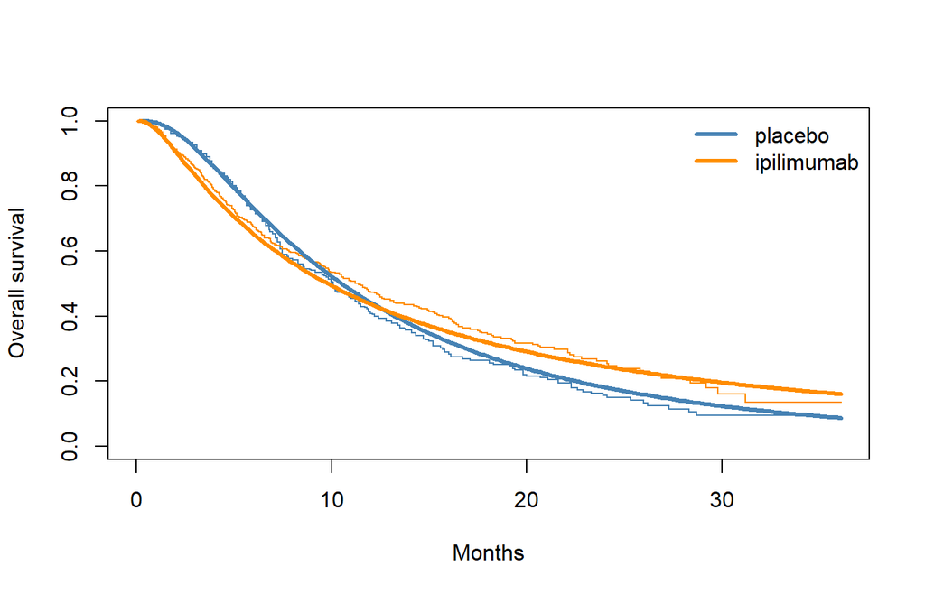

```r
gam.top <- as.integer(fits$GH$post.prob$Vars[1])
M <- map.lcm(gam.top, S$dat)
km <- survfit(Surv(time, status) ~ trt, data = S$df)
plot(km, col = c("steelblue", "darkorange"), xlab = "Months", ylab = "Overall survival")
tt <- seq(0.1, max(S$df$time), length.out = 200)
for (x in 0:1) lines(tt, S.gh.lnorm(tt, x, M$mu, M$sigma, M$alpha, M$beta),
                     col = c("steelblue", "darkorange")[x + 1], lwd = 3)
legend("topright", c("placebo", "ipilimumab"), col = c("steelblue", "darkorange"), lwd = 3, bty = "n")
```

## Adding a noise covariate

With an irrelevant standard normal covariate added (`noise = TRUE`), the joint analysis still includes the treatment, while the restricted analyses do not:

```r
S2 <- prep.ipilimumab(noise = TRUE, file = "real_application/data/CA184043_2A.csv")
fits2 <- lapply(spaces, function(h) fit.space(S2$dat, h))
sapply(fits2, function(f) {
  G <- do.call(rbind, lapply(strsplit(f$post.prob$Vars, ""), as.integer))
  round(setNames(colSums(f$post.prob$prob * (G != 0)), colnames(S2$dat$x)), 3)
})
```

```
        GH    PH   AFT
trt  0.999 0.122 0.031
spur 0.098 0.079 0.106
```